# DA5030.Proj.Aggarwal

# Top 10 Restaurants by reactions

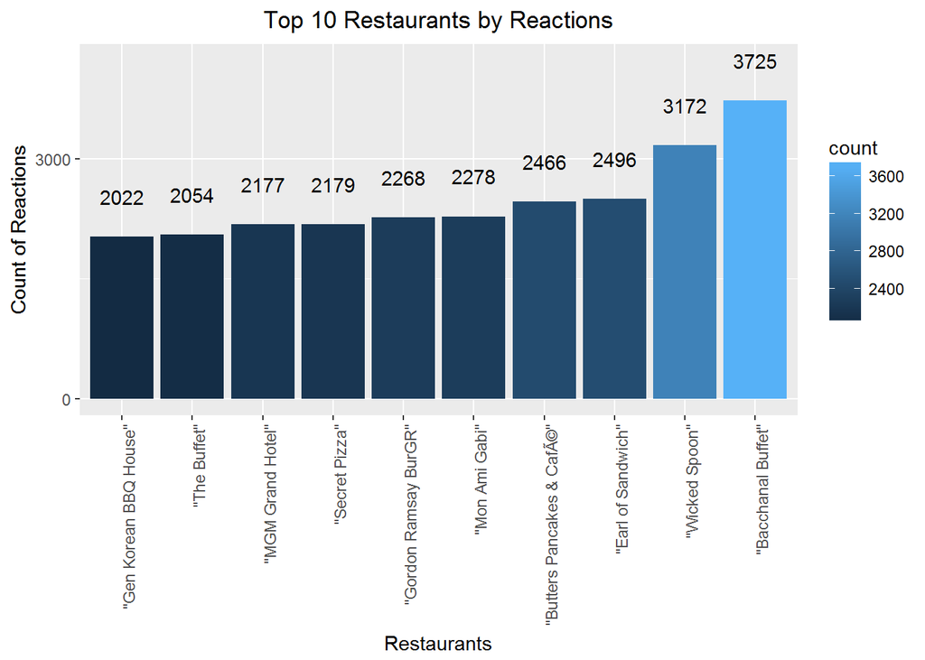

```r
review_reactions <- sqldf("SELECT name,r.reactions AS count
                          FROM review r
                          INNER JOIN business b on r.business_id = b.business_id
                          ORDER BY 2 desc
                          LIMIT 10")

ggplot(data=review_reactions, aes(x=factor(name, levels = name[order(count)]),y=count,fill=count,label = count)) +
  geom_col() + geom_text(nudge_y = 500) +
  theme(axis.text.x = element_text(angle = 90, hjust = 1)) +
  scale_y_continuous(breaks = seq(0,18000,3000)) +
  labs(x="Restaurants",y="Count of Reactions", title="Top 10 Restaurants by Reactions")+
  theme(plot.title = element_text(hjust = 0.5))
```

# Star Rating Histogram

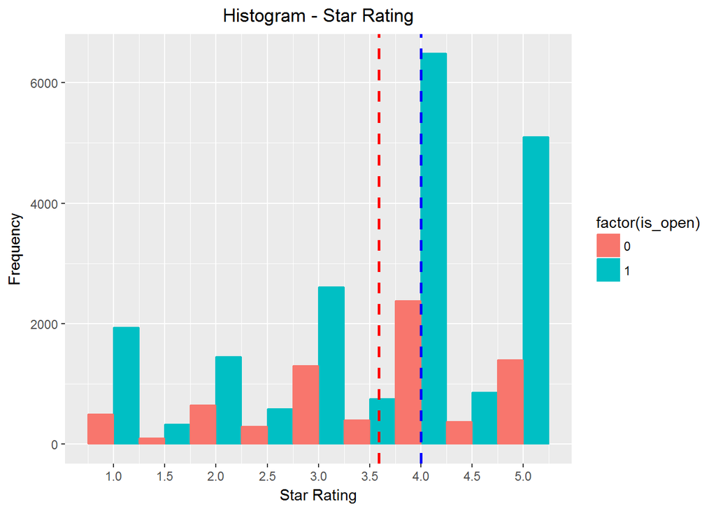

```r
review_star <- sqldf("SELECT r.business_id,r.stars,b.is_open,review_age_wks
                     FROM review r
                     INNER JOIN business b on r.business_id = b.business_id
                     ORDER BY 2 desc")

ggplot(review_star, aes(x=Stars,fill=factor(is_open),color=factor(is_open))) +
  geom_histogram(position="dodge", binwidth=.5) +
  scale_x_continuous(breaks = seq(0,5,0.5)) +
  geom_vline(aes(xintercept=mean(review_star$Stars,na.rm = 1)),
             color="red", linetype="dashed", size=1) +
  geom_vline(aes(xintercept=median(review_star$Stars,na.rm = 1)),
             color="blue", linetype="dashed", size=1) +
  labs(y="Frequency", x="Star Rating", title="Histogram - Star Rating") +
  theme(plot.title = element_text(hjust = 0.5))
```

# Age of Reviews Histogram

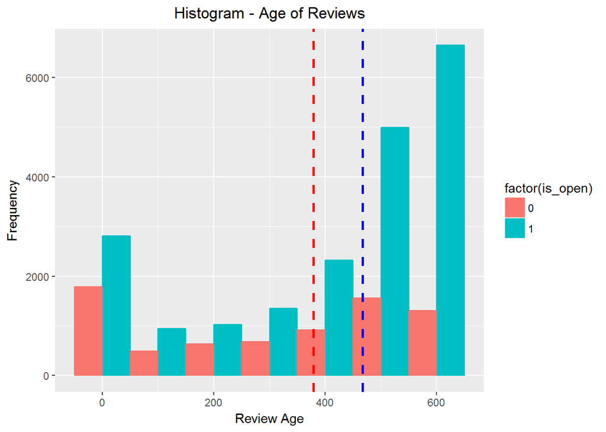

```r
ggplot(review_star, aes(x=review_age_wks,fill=factor(is_open),color=factor(is_open))) +
  geom_histogram(position="dodge", binwidth=100) +
  geom_vline(aes(xintercept=mean(review_star$review_age_wks,na.rm = 1)),
             color="red", linetype="dashed", size=1) +
  geom_vline(aes(xintercept=median(review_star$review_age_wks,na.rm = 1)),
             color="blue", linetype="dashed", size=1) +
  labs(y="Frequency", x="Review Age", title="Histogram - Age of Reviews") +
  theme(plot.title = element_text(hjust = 0.5))
```

## business_hrs Exploratory Analysis

```r
str(business_hrs)
```

```
## 'data.frame':    32478 obs. of  8 variables:
##  $ business_id: chr  "PfOCPjBrlQAnz__NXj9h_w" "XOSRcvtaKc_Q5H1SAzN20A" "fNMVV_ZX7CJSDWQGdOM8Nw" "Dj0S-Oe4ytRJzMGUPgYUkw" ...
##  $ monday     : num  14 0 8 14.5 8 14 6 0 11 14 ...
##  $ tuesday    : num  14 0 8 14.5 8 14 6 0 11 14 ...
##  $ wednesday  : num  14 0 8 14.5 8 14 6 0 11 14 ...
##  $ thursday   : num  14 0 8 14.5 8 14 6 0 11 14 ...
##  $ friday     : num  14 0 8 15.5 8 14 12 0 12 14 ...
##  $ saturday   : num  15 0 0 15 8 15 12 0 12 14 ...
##  $ sunday     : num  13 0 0 13 8 0 10 0 10 14 ...
```

```r
summary(business_hrs)
```

```
##  business_id            monday          tuesday         wednesday
##  Length:32478       Min.   : 0.000   Min.   : 0.000   Min.   : 0.00
##  Class :character   1st Qu.: 0.000   1st Qu.: 0.000   1st Qu.: 0.00
##  Mode  :character   Median :10.000   Median :10.000   Median :10.00
##                     Mean   : 7.248   Mean   : 7.619   Mean   : 7.70
##                     3rd Qu.:11.500   3rd Qu.:11.500   3rd Qu.:11.50
##                     Max.   :23.980   Max.   :23.980   Max.   :23.98
##     thursday          friday          saturday          sunday
##  Min.   : 0.000   Min.   : 0.000   Min.   : 0.000   Min.   : 0.000
##  1st Qu.: 0.000   1st Qu.: 0.000   1st Qu.: 0.000   1st Qu.: 0.000
##  Median :10.000   Median :10.000   Median :10.000   Median : 7.500
##  Mean   : 7.756   Mean   : 8.137   Mean   : 7.948   Mean   : 6.446
##  3rd Qu.:12.000   3rd Qu.:12.000   3rd Qu.:12.000   3rd Qu.:11.000
##  Max.   :23.980   Max.   :23.980   Max.   :23.980   Max.   :23.980
```

# Average hours of operation day wise

```r
hrs_avg <- sqldf("SELECT avg(monday) AS Monday
                 ,avg(tuesday) AS Tuesday
                 ,avg(wednesday) AS Wednesday
                 ,avg(thursday) AS Thursday
                 ,avg(friday) AS Friday
                 ,avg(saturday) AS Saturday
                 ,avg(sunday) AS Sunday
                 FROM business_hrs bh
                 INNER JOIN business b on bh.business_id = b.business_id")

hrs_avg <- melt(hrs_avg)
```

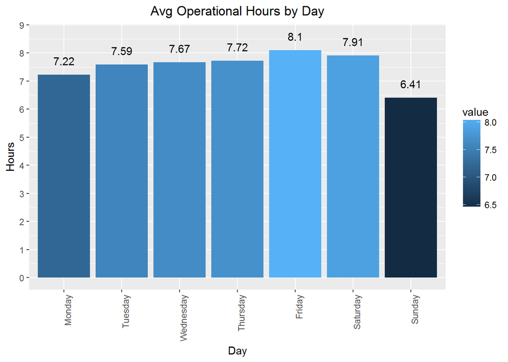

```r
hrs_avg$value <- round(hrs_avg$value,2)


ggplot(data=hrs_avg, aes(x=variable,y=value,fill=value,label = value)) +
  geom_col() + geom_text(nudge_y = 0.5) +
  theme(axis.text.x = element_text(angle = 90, hjust = 1)) +
  scale_y_continuous(breaks = seq(0,10,1)) +
  labs(x="Day",y="Hours", title="Avg Operational Hours by Day")+
  theme(plot.title = element_text(hjust = 0.5))
```

# Assigning dummy code to consider if the restaurant is open on Weekends, Weekdays and sundays

```r
business_hrs <- sqldf("SELECT b.business_id
                       ,monday
                       ,tuesday
                       ,wednesday
                       ,thursday
                       ,friday
                       ,saturday
                       ,sunday
                       ,CASE WHEN sunday > 0
                             THEN 1
                             ELSE 0
                       END is_sunday
                       ,CASE WHEN sunday > 0 AND saturday > 0
                             THEN 1
                             ELSE 0
                       END is_weekend
                       ,CASE WHEN monday > 0 AND tuesday > 0 AND wednesday > 0 AND thursday > 0 AND friday > 0
                             THEN 1
                             ELSE 0
                       END is_weekday
                       FROM business_hrs bh
                       INNER JOIN business b on bh.business_id = b.business_id")
```

## ——————————————————————————-

# 4. Data Consolidation

## ——————————————————————————-

```r
str(business)
```

```
## 'data.frame':    30457 obs. of  11 variables:
##  $ business_id : Factor w/ 174567 levels "--6MefnULPED_I942VcFNA",..: 116532 161622 63445 51651 66747 140227 127022 10541 116099 18293 ...
##  $ name        : Factor w/ 132619 levels "\"'1871' Berkeley Church\"",..: 18461 37456 103909 85724 121132 131929 74142 24583 43506 110043 ...
##  $ city        : chr  "Cuyahoga Falls" "Houston" "Charlotte" "Elyria" ...
##  $ state       : chr  "OH" "PA" "NC" "OH" ...
##  $ postal_code : chr  "44221" "15342" "28202" "44035" ...
##  $ postal_res  : int  75 5 286 90 95 178 127 127 441 441 ...
##  $ is_open     : int  1 0 1 1 0 1 1 1 1 1 ...
##  $ longitude   : num  -81.5 -80.2 -80.8 -82.1 -81 ...
##  $ latitude    : num  41.1 40.2 35.2 41.4 35 ...
##  $ stars       : num  3.5 4.5 3.5 2 3.5 3.5 1 3 4 2.5 ...
##  $ review_count: int  116 3 7 4 6 78 10 232 13 6 ...
```

```r
str(review)
```

```
## 'data.frame':    29294 obs. of  7 variables:
##  $ business_id     : chr  "--9e1ONYQuAa-CB_Rrw7Tw" "--FBCX-N37CMYDfs790Bnw" "--GM_ORV2cYS-h38DSaCLw" "--I7YYLada0tSLkORTHb5Q" ...
##  $ review_count    : int  302 29 4 15 2 1 1 66 4 19 ...
##  $ Stars           : num  5 4 4 4 4 2 1 4 5 4 ...
##  $ review_age_wks  : num  609 576 151 552 177 1 1 596 562 551 ...
##  $ review_per_wk   : num  0.4959 0.0503 0.0265 0.0272 0.0113 ...
##  $ reactions       : int  560 54 4 6 2 1 0 117 2 29 ...
##  $ reactions_per_wk: int  404 38 2 5 2 1 0 95 1 21 ...
```

```r
str(business_hrs)
```

```
## 'data.frame':    30453 obs. of  11 variables:
##  $ business_id: chr  "PfOCPjBrlQAnz__NXj9h_w" "XOSRcvtaKc_Q5H1SAzN20A" "fNMVV_ZX7CJSDWQGdOM8Nw" "Dj0S-Oe4ytRJzMGUPgYUkw" ...
##  $ monday     : num  14 0 8 14.5 8 14 0 11 14 0 ...
##  $ tuesday    : num  14 0 8 14.5 8 14 0 11 14 0 ...
##  $ wednesday  : num  14 0 8 14.5 8 14 0 11 14 0 ...
##  $ thursday   : num  14 0 8 14.5 8 14 0 11 14 0 ...
##  $ friday     : num  14 0 8 15.5 8 14 0 12 14 0 ...
##  $ saturday   : num  15 0 0 15 8 15 0 12 14 0 ...
##  $ sunday     : num  13 0 0 13 8 0 0 10 14 0 ...
##  $ is_sunday  : int  1 0 0 1 1 0 0 1 1 0 ...
##  $ is_weekend : int  1 0 0 1 1 0 0 1 1 0 ...
##  $ is_weekday : int  1 0 1 1 1 1 0 1 1 0 ...
```

```r
business_final <- sqldf("select b.business_id,postal_code,b.postal_res,r.review_count,r.Stars,r.review_age_wks,r.review_per_wk,reactions_per_wk,reactions
                        ,monday+tuesday+wednesday+thursday+friday+saturday+sunday AS total_open_hrs
                        ,is_weekend,is_weekday,is_sunday,is_open
                        FROM business b
                        INNER JOIN review r ON b.business_id = r.business_id
                        INNER JOIN business_hrs bh ON b.business_id = bh.business_id")
```

# Aggregating average reactions by Postal Code

```r
postal_reac <- sqldf("select postal_code
                     ,avg(reactions) AS postal_reac
                     FROM business_final
                     GROUP BY postal_code
                     ORDER BY 2 DESC")
```

# Final Consolidation

```r
business_final <- sqldf("select postal_res,review_count,Stars,review_age_wks,review_per_wk,reactions_per_wk,reactions,postal_reac
                        ,total_open_hrs,population,is_weekend,is_weekday,is_sunday,is_open
                        FROM business_final b
                        INNER JOIN postal_reac p ON b.postal_code = p.postal_code
                        INNER JOIN pop po ON po.zip_code = b.postal_code")

str(business_final)
```

```
## 'data.frame':    27274 obs. of  14 variables:
##  $ postal_res      : int  75 5 286 90 95 178 127 127 441 441 ...
##  $ review_count    : int  30 2 2 2 1 8 2 40 2 56 ...
##  $ Stars           : num  3 4.5 3 1.5 4 5 1.5 3 4.5 3 ...
##  $ review_age_wks  : num  599 560 180 401 1 454 214 605 256 608 ...
##  $ review_per_wk   : num  0.05008 0.00357 0.01111 0.00499 1 ...
##  $ reactions_per_wk: int  46 2 1 0 0 4 18 94 0 170 ...
##  $ reactions       : int  51 2 1 0 0 6 20 112 1 217 ...
##  $ postal_reac     : num  8.75 4.8 30 4.19 7.71 ...
##  $ total_open_hrs  : num  98 0 40 102 56 ...
##  $ population      : int  29778 4903 10543 63921 27082 51833 47376 47376 46693 46693 ...
##  $ is_weekend      : int  1 0 0 1 1 0 0 1 1 1 ...
##  $ is_weekday      : int  1 0 1 1 1 1 0 1 1 1 ...
##  $ is_sunday       : int  1 0 0 1 1 0 0 1 1 1 ...
##  $ is_open         : int  1 0 1 1 0 1 1 1 1 1 ...
```

```r
business_final <- as.data.frame(sapply( business_final, as.integer ))
```

# Correlation/Collinearity Analysis

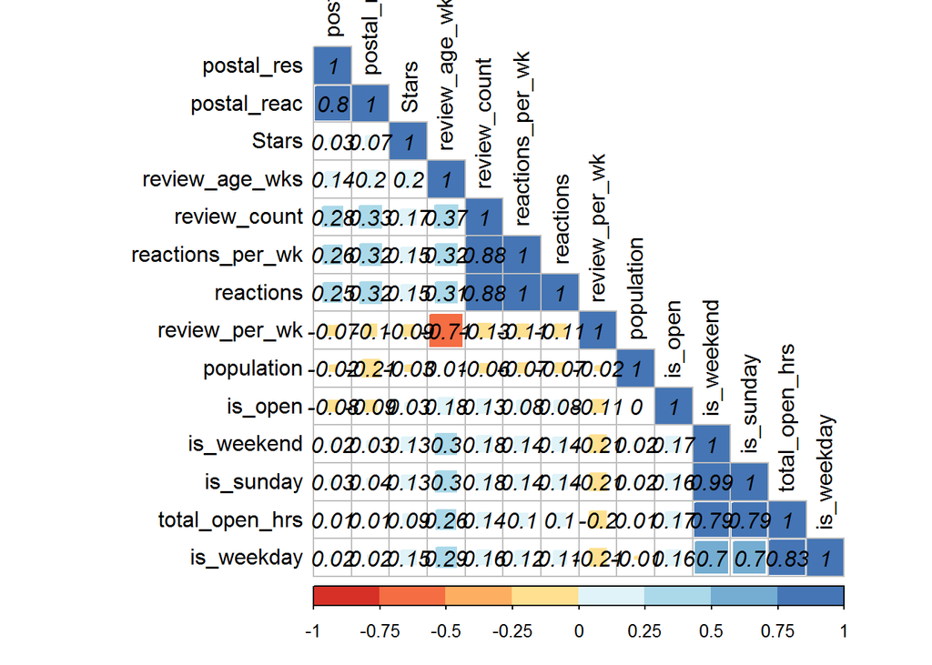

```r
corMatrix <- cor(business_final)

corrplot(corMatrix, method="square", col = brewer.pal(n=8, name="RdYlBu"),
         type="lower", order="hclust", number.font = 3,
         addCoef.col = "black", # Add coefficient of correlation
         tl.col="black", tl.srt=90, #Text label color and rotation
         diag=TRUE, sig.level = 0.05, insig = "blank")
```

# Density Plot

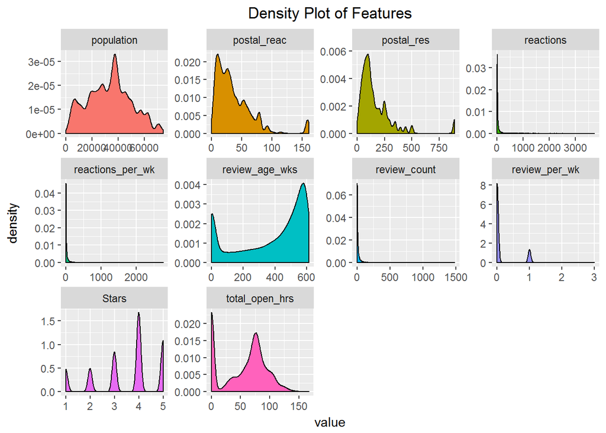

```r
business_final %>%
  select(-c(is_open,is_weekday,is_weekend,is_sunday)) %>%
  gather(metric, value) %>%
  ggplot(aes(value, fill = metric)) +
  geom_density(show.legend = FALSE) +
  facet_wrap(~ metric, scales = "free") +
  ggtitle("Density Plot of Features") +
  theme(plot.title = element_text(hjust = 0.5))
```

# ——————————————————————————–

# Removing unnecassary objects

# ——————————————————————————–

```r
rm(business)
rm(business_cat)
rm(business_city)
rm(business_hrs)
rm(business_hrs_raw)
rm(business_star)
rm(categories)
rm(pop)
rm(postal_res)
rm(us)
rm(corMatrix)
rm(hrs_avg)
rm(review)
rm(review_cnt)
rm(review_reactions)
rm(review_star)
rm(postal_reac)
```

## ——————————————————————————-

# 5. Model Preperation

## ——————————————————————————-

# Spliting data set into training and validation

```r
set.seed(123)
spec <- c(train = .7, validation = .3)

g <- sample(cut(
  seq(nrow(business_final)),
  nrow(business_final)*cumsum(c(0,spec)),
  labels = names(spec)
))

set.seed(123)
res <- split(business_final, g)
train_set <- res$train
val_set <- res$validation

ctrl <- trainControl(method = "cv", number = 10)
```

# Normalization

```r
train_set[, 1:13] <- lapply(train_set[, 1:13], function(x) (x-min(x))/(max(x)-min(x)))
train_set_fac <- train_set
train_set_fac$is_open <- as.factor(train_set_fac$is_open)

val_set[, 1:13] <- lapply(val_set[, 1:13], function(x) (x-min(x))/(max(x)-min(x)))
val_set_fac <- val_set
val_set_fac$is_open <- as.factor(val_set_fac$is_open)
```

# Implementation of Principal Component Analysis

```r
prin_comp <- prcomp(train_set[, 1:13], scale. = T)
names(prin_comp)
```

```
## [1] "sdev"     "rotation" "center"   "scale"    "x"
```

```r
#loadings
prin_comp$rotation
```

```
##                          PC1         PC2         PC3         PC4
## postal_res        0.14465774  0.27778788 -0.60174925 -0.11924512
## review_count      0.32614395  0.34429271  0.24305922 -0.08088907
## Stars             0.13392825  0.02658448  0.07981728  0.14605497
## review_age_wks    0.29798869  0.04633393 -0.04445565  0.58474279
## review_per_wk    -0.20678621  0.02248609  0.10843331 -0.69191308
## reactions_per_wk  0.31368951  0.37464050  0.30197918 -0.11751320
## reactions         0.31330535  0.37514894  0.30302409 -0.11917845
## postal_reac       0.17020032  0.30853128 -0.58563723 -0.11202768
## total_open_hrs    0.34041693 -0.33926361 -0.04289662 -0.15058924
## population       -0.02803951 -0.08266057  0.16458570  0.13602968
## is_weekend        0.36668742 -0.32455501 -0.03479206 -0.14699224
## is_weekday        0.33441307 -0.30422692 -0.03533045 -0.11077800
## is_sunday         0.36704021 -0.32377602 -0.03663171 -0.14702015
##                            PC5          PC6          PC7          PC8
## postal_res        0.2232573030  0.143738752 -0.043345470 -0.044371073
## review_count      0.0310829658 -0.032966268 -0.025916937  0.159579848
## Stars            -0.4478060495  0.861172737  0.022326009 -0.087883822
## review_age_wks   -0.0131562586 -0.082907368  0.027097357  0.713614175
## review_per_wk    -0.0050145679  0.198034180  0.011074240  0.636880074
## reactions_per_wk  0.0403517139 -0.069145701 -0.006981151 -0.146081033
## reactions         0.0368560133 -0.062169057 -0.009208698 -0.155013403
## postal_reac       0.0009508479  0.052455755  0.026510758  0.010251882
## total_open_hrs    0.0157924856 -0.050303021 -0.336568004 -0.049528312
## population        0.8610602608  0.419739134 -0.034827914 -0.007838502
## is_weekend        0.0363566259 -0.006827845  0.466333779 -0.022678975
## is_weekday       -0.0347046083  0.018635459 -0.666266836  0.031899523
## is_sunday         0.0356877400 -0.006307535  0.468388808 -0.021451276
##                            PC9        PC10        PC11          PC12
## postal_res       -0.6385697653  0.19246034 -0.08007168  0.0001530113
## review_count     -0.2521044181 -0.74522237  0.24968321 -0.0016117745
## Stars            -0.0167645506  0.02638206  0.04766163  0.0009321959
## review_age_wks    0.0137091035  0.21807515 -0.01812766  0.0017707174
## review_per_wk     0.0323055561  0.14128053 -0.01537533  0.0010985863
## reactions_per_wk  0.0909993504  0.33209931 -0.11074336 -0.0069989083
## reactions         0.0948108699  0.32227838 -0.10319539  0.0078498243
## postal_reac       0.6937109502 -0.17086711  0.07945465  0.0018832009
## total_open_hrs   -0.0001834668  0.25011960  0.75057247  0.0078399324
## population        0.1603895518 -0.04220542  0.02003587 -0.0003827543
## is_weekend       -0.0137485253 -0.04470671 -0.13060290  0.7062250658
## is_weekday        0.0510000953 -0.16815012 -0.55198517 -0.0070278643
## is_sunday        -0.0118169243 -0.03776925 -0.11695525 -0.7078228388
##                           PC13
## postal_res        0.0032216128
## review_count     -0.0049155011
## Stars            -0.0057719109
## review_age_wks    0.0072687243
## review_per_wk     0.0030566006
## reactions_per_wk -0.7053799675
## reactions         0.7086432471
## postal_reac      -0.0034143473
## total_open_hrs   -0.0028381855
## population       -0.0008143625
## is_weekend       -0.0062085471
## is_weekday        0.0007849996
## is_sunday         0.0086184853
```

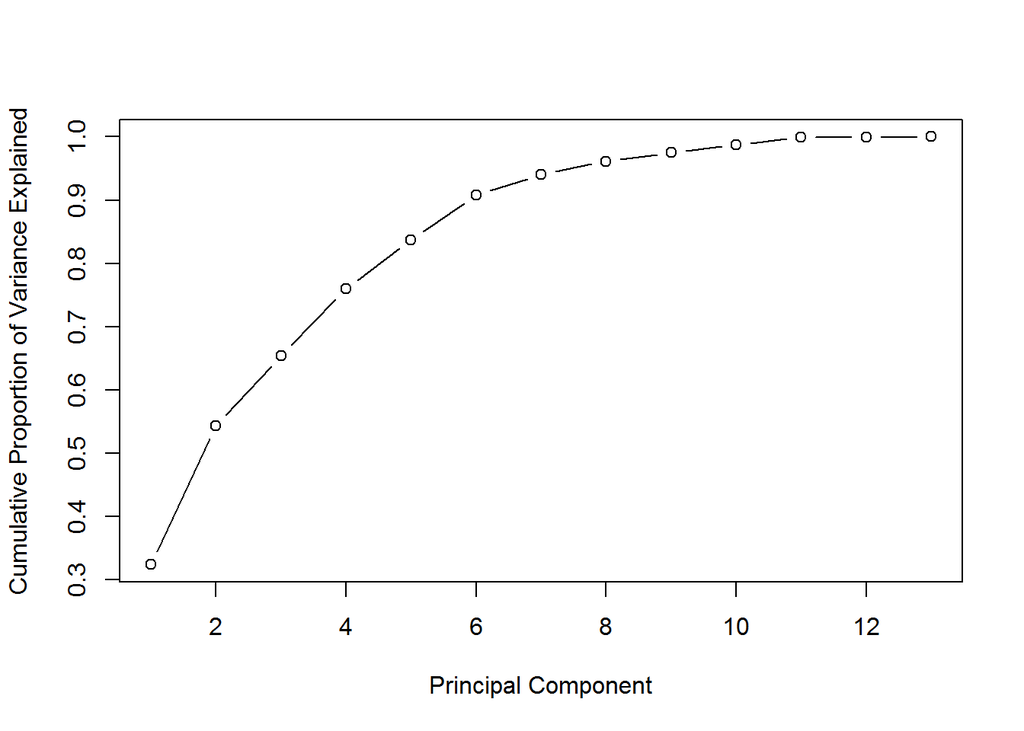

```r
std_dev <- prin_comp$sdev
pr_var <- std_dev^2
prop_varex <- pr_var/sum(pr_var)

plot(cumsum(prop_varex), xlab = "Principal Component",
     ylab = "Cumulative Proportion of Variance Explained",
     type = "b")
```

```r
train_set_pca <- data.frame(is_open = train_set$is_open,prin_comp$x)
```

# we are interested in first 6 PCA explaining more than 90% variance

```r
train_set_pca  <- train_set_pca [,1:7]


val_set_pca <- predict(prin_comp, newdata = val_set[,1:13])
val_set_pca <- as.data.frame(val_set_pca)
val_set_pca <- val_set_pca[,1:7]
```

## ——————————————————————————-

# 5. Model Construction

## ——————————————————————————-

## Logistic Regression

# Train Accuracy: 73.72%

# Validation Accuracy: 73.36%

# AUC: 0.71

```r
log_model_raw <- glm(is_open~., data=train_set,  family=binomial )
summary(log_model_raw)
```

```
##
## Call:
## glm(formula = is_open ~ ., family = binomial, data = train_set)
##
## Deviance Residuals:
##     Min       1Q   Median       3Q      Max
## -6.2012  -1.0805   0.6137   0.8012   4.0731
##
## Coefficients:
##                   Estimate Std. Error z value Pr(>|z|)
## (Intercept)        0.83405    0.07561  11.031  < 2e-16 ***
## postal_res         0.04626    0.15757   0.294 0.769062
## review_count      48.10849    2.72917  17.628  < 2e-16 ***
## Stars             -0.25372    0.05562  -4.562 5.08e-06 ***
## review_age_wks     0.66041    0.07969   8.288  < 2e-16 ***
## review_per_wk      0.26184    0.18991   1.379 0.167962
## reactions_per_wk -61.75774   11.40405  -5.415 6.11e-08 ***
## reactions         42.78190   11.07930   3.861 0.000113 ***
## postal_reac       -2.26851    0.15575 -14.565  < 2e-16 ***
## total_open_hrs     0.91248    0.16446   5.548 2.88e-08 ***
## population        -0.37548    0.08195  -4.582 4.61e-06 ***
## is_weekend         0.10209    0.32770   0.312 0.755406
## is_weekday         0.03620    0.06637   0.545 0.585510
## is_sunday         -0.02923    0.32876  -0.089 0.929160
## ---
## Signif. codes:  0 '***' 0.001 '**' 0.01 '*' 0.05 '.' 0.1 ' ' 1
##
## (Dispersion parameter for binomial family taken to be 1)
##
##     Null deviance: 22203  on 19090  degrees of freedom
## Residual deviance: 20250  on 19077  degrees of freedom
## AIC: 20278
##
## Number of Fisher Scoring iterations: 6
```

# Removing is_sunday

```r
log_model <- glm(is_open~postal_res+review_count+Stars+review_age_wks+review_per_wk+reactions_per_wk+reactions+
                   postal_reac+total_open_hrs+population+is_weekend+is_weekday, data=train_set,  family=binomial )
summary(log_model)
```

```
##
## Call:
## glm(formula = is_open ~ postal_res + review_count + Stars + review_age_wks +
##     review_per_wk + reactions_per_wk + reactions + postal_reac +
##     total_open_hrs + population + is_weekend + is_weekday, family = binomial,
##     data = train_set)
##
## Deviance Residuals:
##     Min       1Q   Median       3Q      Max
## -6.2010  -1.0804   0.6137   0.8010   4.0732
##
## Coefficients:
##                   Estimate Std. Error z value Pr(>|z|)
## (Intercept)        0.83411    0.07561  11.032  < 2e-16 ***
## postal_res         0.04630    0.15757   0.294 0.768857
## review_count      48.10781    2.72913  17.628  < 2e-16 ***
## Stars             -0.25382    0.05561  -4.564 5.02e-06 ***
## review_age_wks     0.66030    0.07968   8.287  < 2e-16 ***
## review_per_wk      0.26166    0.18990   1.378 0.168234
## reactions_per_wk -61.76642   11.40370  -5.416 6.08e-08 ***
## reactions         42.79031   11.07899   3.862 0.000112 ***
## postal_reac       -2.26878    0.15572 -14.570  < 2e-16 ***
## total_open_hrs     0.91107    0.16369   5.566 2.61e-08 ***
## population        -0.37548    0.08195  -4.582 4.61e-06 ***
## is_weekend         0.07344    0.05976   1.229 0.219101
## is_weekday         0.03644    0.06632   0.549 0.582676
## ---
## Signif. codes:  0 '***' 0.001 '**' 0.01 '*' 0.05 '.' 0.1 ' ' 1
##
## (Dispersion parameter for binomial family taken to be 1)
##
##     Null deviance: 22203  on 19090  degrees of freedom
## Residual deviance: 20250  on 19078  degrees of freedom
## AIC: 20276
##
## Number of Fisher Scoring iterations: 6
```

# Removing postal_res

```r
log_model <- glm(is_open~review_count+Stars+review_age_wks+review_per_wk+reactions_per_wk+reactions+
                   postal_reac+total_open_hrs+population+is_weekend+is_weekday, data=train_set,  family=binomial )
summary(log_model)
```

```
##
## Call:
## glm(formula = is_open ~ review_count + Stars + review_age_wks +
##     review_per_wk + reactions_per_wk + reactions + postal_reac +
##     total_open_hrs + population + is_weekend + is_weekday, family = binomial,
##     data = train_set)
##
## Deviance Residuals:
##     Min       1Q   Median       3Q      Max
## -6.1998  -1.0821   0.6139   0.8013   4.0742
##
## Coefficients:
##                   Estimate Std. Error z value Pr(>|z|)
## (Intercept)        0.83205    0.07528  11.053  < 2e-16 ***
## review_count      48.13407    2.72779  17.646  < 2e-16 ***
## Stars             -0.25434    0.05559  -4.576 4.75e-06 ***
## review_age_wks     0.66008    0.07967   8.286  < 2e-16 ***
## review_per_wk      0.26217    0.18988   1.381 0.167362
## reactions_per_wk -61.72881   11.40591  -5.412 6.23e-08 ***
## reactions         42.72582   11.07912   3.856 0.000115 ***
## postal_reac       -2.23276    0.09606 -23.243  < 2e-16 ***
## total_open_hrs     0.91151    0.16368   5.569 2.57e-08 ***
## population        -0.36923    0.07913  -4.666 3.07e-06 ***
## is_weekend         0.07309    0.05974   1.223 0.221171
## is_weekday         0.03666    0.06631   0.553 0.580324
## ---
## Signif. codes:  0 '***' 0.001 '**' 0.01 '*' 0.05 '.' 0.1 ' ' 1
##
## (Dispersion parameter for binomial family taken to be 1)
##
##     Null deviance: 22203  on 19090  degrees of freedom
## Residual deviance: 20250  on 19079  degrees of freedom
## AIC: 20274
##
## Number of Fisher Scoring iterations: 6
```

# Removing is_weekday

```r
log_model <- glm(is_open~review_count+Stars+review_age_wks+review_per_wk+reactions_per_wk+reactions+
                   postal_reac+total_open_hrs+population+is_weekend, data=train_set,  family=binomial )
summary(log_model)
```

```
##
## Call:
## glm(formula = is_open ~ review_count + Stars + review_age_wks +
##     review_per_wk + reactions_per_wk + reactions + postal_reac +
##     total_open_hrs + population + is_weekend, family = binomial,
##     data = train_set)
##
## Deviance Residuals:
##     Min       1Q   Median       3Q      Max
## -6.2061  -1.0819   0.6144   0.8016   4.0807
##
## Coefficients:
##                   Estimate Std. Error z value Pr(>|z|)
## (Intercept)        0.83381    0.07521  11.086  < 2e-16 ***
## review_count      48.23218    2.72347  17.710  < 2e-16 ***
## Stars             -0.25103    0.05526  -4.542 5.56e-06 ***
## review_age_wks     0.66087    0.07965   8.297  < 2e-16 ***
## review_per_wk      0.26077    0.18985   1.374 0.169577
## reactions_per_wk -61.82181   11.40580  -5.420 5.95e-08 ***
## reactions         42.77643   11.08048   3.861 0.000113 ***
## postal_reac       -2.23378    0.09605 -23.257  < 2e-16 ***
## total_open_hrs     0.97051    0.12415   7.817 5.41e-15 ***
## population        -0.37047    0.07909  -4.684 2.81e-06 ***
## is_weekend         0.07528    0.05957   1.264 0.206313
## ---
## Signif. codes:  0 '***' 0.001 '**' 0.01 '*' 0.05 '.' 0.1 ' ' 1
##
## (Dispersion parameter for binomial family taken to be 1)
##
##     Null deviance: 22203  on 19090  degrees of freedom
## Residual deviance: 20251  on 19080  degrees of freedom
## AIC: 20273
##
## Number of Fisher Scoring iterations: 6
```

# Removing is_weekend

```r
log_model <- glm(is_open~review_count+Stars+review_age_wks+review_per_wk+reactions_per_wk+reactions+
                   postal_reac+total_open_hrs+population, data=train_set,  family=binomial )
summary(log_model)
```

```
##
## Call:
## glm(formula = is_open ~ review_count + Stars + review_age_wks +
##     review_per_wk + reactions_per_wk + reactions + postal_reac +
##     total_open_hrs + population, family = binomial, data = train_set)
##
## Deviance Residuals:
##     Min       1Q   Median       3Q      Max
## -6.2282  -1.0838   0.6154   0.8014   4.0819
##
## Coefficients:
##                   Estimate Std. Error z value Pr(>|z|)
## (Intercept)        0.83193    0.07520  11.063  < 2e-16 ***
## review_count      48.48633    2.71935  17.830  < 2e-16 ***
## Stars             -0.24774    0.05521  -4.488 7.21e-06 ***
## review_age_wks     0.66443    0.07962   8.345  < 2e-16 ***
## review_per_wk      0.26059    0.18984   1.373 0.169836
## reactions_per_wk -61.64253   11.39482  -5.410 6.31e-08 ***
## reactions         42.60066   11.07103   3.848 0.000119 ***
## postal_reac       -2.23403    0.09606 -23.257  < 2e-16 ***
## total_open_hrs     1.09510    0.07566  14.473  < 2e-16 ***
## population        -0.36688    0.07904  -4.642 3.46e-06 ***
## ---
## Signif. codes:  0 '***' 0.001 '**' 0.01 '*' 0.05 '.' 0.1 ' ' 1
##
## (Dispersion parameter for binomial family taken to be 1)
##
##     Null deviance: 22203  on 19090  degrees of freedom
## Residual deviance: 20252  on 19081  degrees of freedom
## AIC: 20272
##
## Number of Fisher Scoring iterations: 6
```

# Removing review_per_wk

```r
log_model <- glm(is_open~review_count+Stars+review_age_wks+reactions_per_wk+reactions+
                   postal_reac+total_open_hrs+population, data=train_set,  family=binomial)
summary(log_model)
```

```
##
## Call:
## glm(formula = is_open ~ review_count + Stars + review_age_wks +
##     reactions_per_wk + reactions + postal_reac + total_open_hrs +
##     population, family = binomial, data = train_set)
##
## Deviance Residuals:
##     Min       1Q   Median       3Q      Max
## -6.2508  -1.0818   0.6167   0.8016   4.0829
##
## Coefficients:
##                   Estimate Std. Error z value Pr(>|z|)
## (Intercept)        0.88572    0.06426  13.783  < 2e-16 ***
## review_count      48.97536    2.70146  18.129  < 2e-16 ***
## Stars             -0.24439    0.05514  -4.432 9.32e-06 ***
## review_age_wks     0.58970    0.05819  10.135  < 2e-16 ***
## reactions_per_wk -61.46428   11.37854  -5.402 6.60e-08 ***
## reactions         42.38165   11.05804   3.833 0.000127 ***
## postal_reac       -2.23643    0.09605 -23.285  < 2e-16 ***
## total_open_hrs     1.09088    0.07560  14.430  < 2e-16 ***
## population        -0.36765    0.07904  -4.652 3.29e-06 ***
## ---
## Signif. codes:  0 '***' 0.001 '**' 0.01 '*' 0.05 '.' 0.1 ' ' 1
##
## (Dispersion parameter for binomial family taken to be 1)
##
##     Null deviance: 22203  on 19090  degrees of freedom
## Residual deviance: 20254  on 19082  degrees of freedom
## AIC: 20272
##
## Number of Fisher Scoring iterations: 6
```

# Train Accuracy

```r
pred <- predict(log_model,train_set,type = "response")
pred <- ifelse(pred > 0.5,1,0)

caret::confusionMatrix(data = as.factor(pred), reference = as.factor(train_set$is_open))
```

```
## Confusion Matrix and Statistics
##
##           Reference
## Prediction     0     1
##          0   625   522
##          1  4496 13448
##
##                Accuracy : 0.7372
##                  95% CI : (0.7308, 0.7434)
##     No Information Rate : 0.7318
##     P-Value [Acc > NIR] : 0.0468
##
##                   Kappa : 0.1123
##  Mcnemar's Test P-Value : <2e-16
##
##             Sensitivity : 0.12205
##             Specificity : 0.96263
##          Pos Pred Value : 0.54490
##          Neg Pred Value : 0.74944
##              Prevalence : 0.26824
##          Detection Rate : 0.03274
##    Detection Prevalence : 0.06008
##       Balanced Accuracy : 0.54234
##
##        'Positive' Class : 0
##
```

# Validation Accuracy

```r
pred <- predict(log_model,val_set,type = "response")
pred <- ifelse(pred > 0.5,1,0)

caret::confusionMatrix(data = as.factor(pred), reference = as.factor(val_set$is_open))
```

```
## Confusion Matrix and Statistics
##
##           Reference
## Prediction    0    1
##          0  255  272
##          1 1908 5748
##
##                Accuracy : 0.7336
##                  95% CI : (0.7239, 0.7431)
##     No Information Rate : 0.7357
##     P-Value [Acc > NIR] : 0.6701
##
##                   Kappa : 0.096
##  Mcnemar's Test P-Value : <2e-16
##
##             Sensitivity : 0.11789
##             Specificity : 0.95482
##          Pos Pred Value : 0.48387
##          Neg Pred Value : 0.75078
##              Prevalence : 0.26433
##          Detection Rate : 0.03116
##    Detection Prevalence : 0.06440
##       Balanced Accuracy : 0.53635
##
##        'Positive' Class : 0
##
```

# ROC

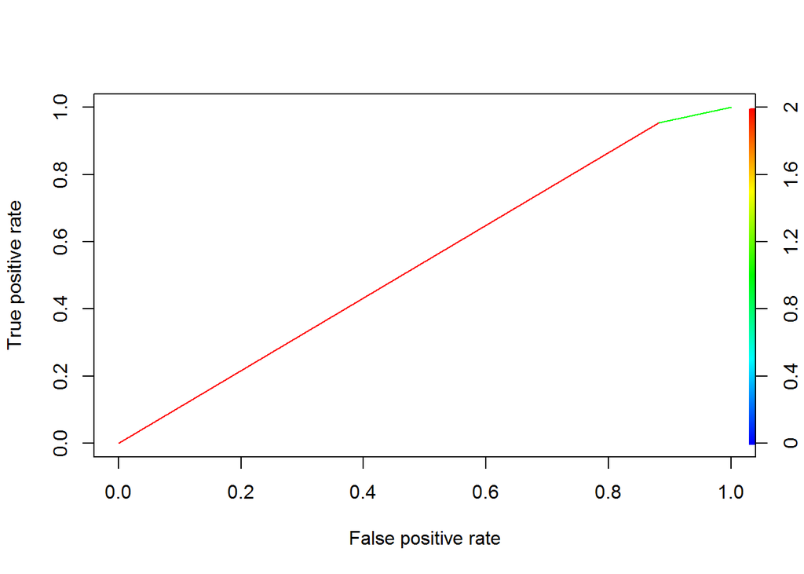

```r
ROCRpred <- prediction(pred, val_set$is_open)
ROCRperf <- performance(ROCRpred, 'tpr','fpr')
plot(ROCRperf, colorize = TRUE, text.adj = c(-0.2,1.7))
```

# AUC

# We can label this a an fairly good classisfier but it doing a good job in the classification with AUC of 0.71

# which is significanlty higher than the other models

```r
auc(log_model)
```

```
## [1] 0.7142314
```

# With PCA

# Accuracy: 71.71%

```r
log_model_pca_raw <- glm(is_open~., data=train_set_pca,  family=binomial)
summary(log_model_pca_raw)
```

```
##
## Call:
## glm(formula = is_open ~ ., family = binomial, data = train_set_pca)
##
## Deviance Residuals:
##     Min       1Q   Median       3Q      Max
## -3.9949  -1.1447   0.6391   0.7991   1.9871
##
## Coefficients:
##              Estimate Std. Error z value Pr(>|z|)
## (Intercept)  1.100432   0.017962  61.265  < 2e-16 ***
## PC1          0.281137   0.012049  23.333  < 2e-16 ***
## PC2         -0.008278   0.016063  -0.515    0.606
## PC3          0.334817   0.018405  18.192  < 2e-16 ***
## PC4          0.083986   0.014937   5.623 1.88e-08 ***
## PC5         -0.023576   0.016785  -1.405    0.160
## PC6         -0.147194   0.017541  -8.391  < 2e-16 ***
## ---
## Signif. codes:  0 '***' 0.001 '**' 0.01 '*' 0.05 '.' 0.1 ' ' 1
##
## (Dispersion parameter for binomial family taken to be 1)
##
##     Null deviance: 22203  on 19090  degrees of freedom
## Residual deviance: 20805  on 19084  degrees of freedom
## AIC: 20819
##
## Number of Fisher Scoring iterations: 5
```

# Removing PC2

```r
log_model_pca <- glm(is_open~PC1+PC3+PC4+PC5+PC6, data=train_set_pca,  family=binomial)
summary(log_model_pca)
```

```
##
## Call:
## glm(formula = is_open ~ PC1 + PC3 + PC4 + PC5 + PC6, family = binomial,
##     data = train_set_pca)
##
## Deviance Residuals:
##     Min       1Q   Median       3Q      Max
## -4.0644  -1.1459   0.6403   0.7996   1.9817
##
## Coefficients:
##              Estimate Std. Error z value Pr(>|z|)
## (Intercept)  1.102089   0.017694  62.285  < 2e-16 ***
## PC1          0.284860   0.009718  29.314  < 2e-16 ***
## PC3          0.339936   0.015550  21.860  < 2e-16 ***
## PC4          0.081254   0.013977   5.813 6.12e-09 ***
## PC5         -0.022872   0.016727  -1.367    0.171
## PC6         -0.148351   0.017393  -8.529  < 2e-16 ***
## ---
## Signif. codes:  0 '***' 0.001 '**' 0.01 '*' 0.05 '.' 0.1 ' ' 1
##
## (Dispersion parameter for binomial family taken to be 1)
##
##     Null deviance: 22203  on 19090  degrees of freedom
## Residual deviance: 20806  on 19085  degrees of freedom
## AIC: 20818
##
## Number of Fisher Scoring iterations: 4
```

# Removing PC5

```r
log_model_pca <- glm(is_open~PC1+PC3+PC4+PC6, data=train_set_pca,  family=binomial)
summary(log_model_pca)
```

```
##
## Call:
## glm(formula = is_open ~ PC1 + PC3 + PC4 + PC6, family = binomial,
##     data = train_set_pca)
##
## Deviance Residuals:
##     Min       1Q   Median       3Q      Max
## -4.0768  -1.1476   0.6403   0.8014   1.9890
##
## Coefficients:
##              Estimate Std. Error z value Pr(>|z|)
## (Intercept)  1.102078   0.017694  62.286  < 2e-16 ***
## PC1          0.285389   0.009714  29.378  < 2e-16 ***
## PC3          0.340606   0.015554  21.898  < 2e-16 ***
## PC4          0.080778   0.013974   5.781 7.44e-09 ***
## PC6         -0.148087   0.017408  -8.507  < 2e-16 ***
## ---
## Signif. codes:  0 '***' 0.001 '**' 0.01 '*' 0.05 '.' 0.1 ' ' 1
##
## (Dispersion parameter for binomial family taken to be 1)
##
##     Null deviance: 22203  on 19090  degrees of freedom
## Residual deviance: 20807  on 19086  degrees of freedom
## AIC: 20817
##
## Number of Fisher Scoring iterations: 4
```

# Validation Accuracy

```r
pred_pca <- predict(log_model_pca_raw,val_set_pca)
pred_pca <- ifelse(pred_pca > 0.5,1,0)

caret::confusionMatrix(data = as.factor(pred_pca), reference = as.factor(val_set$is_open))
```

```
## Confusion Matrix and Statistics
##
##           Reference
## Prediction    0    1
##          0  651  803
##          1 1512 5217
##
##                Accuracy : 0.7171
##                  95% CI : (0.7072, 0.7268)
##     No Information Rate : 0.7357
##     P-Value [Acc > NIR] : 0.9999
##
##                   Kappa : 0.1872
##  Mcnemar's Test P-Value : <2e-16
##
##             Sensitivity : 0.30097
##             Specificity : 0.86661
##          Pos Pred Value : 0.44773
##          Neg Pred Value : 0.77530
##              Prevalence : 0.26433
##          Detection Rate : 0.07956
##    Detection Prevalence : 0.17769
##       Balanced Accuracy : 0.58379
##
##        'Positive' Class : 0
##
```

# ROC

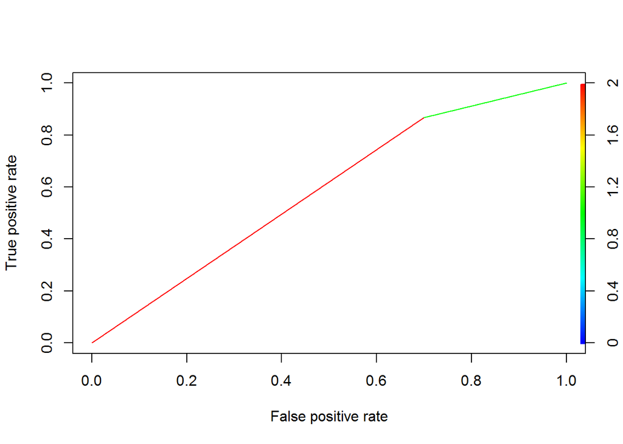

```r
ROCRpred_pca <- prediction(pred_pca, val_set$is_open)
ROCRperf_pca <- performance(ROCRpred_pca, 'tpr','fpr')
plot(ROCRperf_pca, colorize = TRUE, text.adj = c(-0.2,1.7))
```

## Random Forest

# Accuracy: 75.41%

# AUC: 0.59

# Here we will be tuning the model by varying the value mtry. The value for trees (ntree) of 50 and 500 did not give a very big differnce in AUC and Accuracy, so 50 has

# been taken for computional ease.

```r
set.seed(123)

accuracy <- 0
for (i in 1:6) {
  model <- randomForest(is_open ~ ., data = train_set, ntree = 50, mtry = i, importance = TRUE)
  predValid <- predict(model, val_set, type = "response")
  predValid <- ifelse(predValid > 0.5,1,0)
  accuracy_test = mean(predValid == val_set$is_open)
  if (accuracy_test>accuracy) {
    accuracy <- accuracy_test
    optimal_mtry <- i
  }
}
set.seed(123)
rfmodel <- randomForest(is_open ~ ., data = train_set, ntree = 50, mtry = optimal_mtry, importance = TRUE)
rfmodel
```

```
##
## Call:
##  randomForest(formula = is_open ~ ., data = train_set, ntree = 50,      mtry = optimal_mtry, importance = TRUE)
##                Type of random forest: regression
##                      Number of trees: 50
## No. of variables tried at each split: 2
##
##           Mean of squared residuals: 0.1691176
##                     % Var explained: 13.84
```

```r
predValid <- predict(rfmodel, val_set, type = "response")
predValid <- ifelse(predValid > 0.5,1,0)

caret::confusionMatrix(data = as.factor(predValid), reference = as.factor(val_set$is_open))
```

```
## Confusion Matrix and Statistics
##
##           Reference
## Prediction    0    1
##          0  559  408
##          1 1604 5612
##
##                Accuracy : 0.7541
##                  95% CI : (0.7446, 0.7634)
##     No Information Rate : 0.7357
##     P-Value [Acc > NIR] : 7.237e-05
##
##                   Kappa : 0.2317
##  Mcnemar's Test P-Value : < 2.2e-16
##
##             Sensitivity : 0.25844
##             Specificity : 0.93223
##          Pos Pred Value : 0.57808
##          Neg Pred Value : 0.77772
##              Prevalence : 0.26433
##          Detection Rate : 0.06831
##    Detection Prevalence : 0.11817
##       Balanced Accuracy : 0.59533
##
##        'Positive' Class : 0
##
```

# ROC

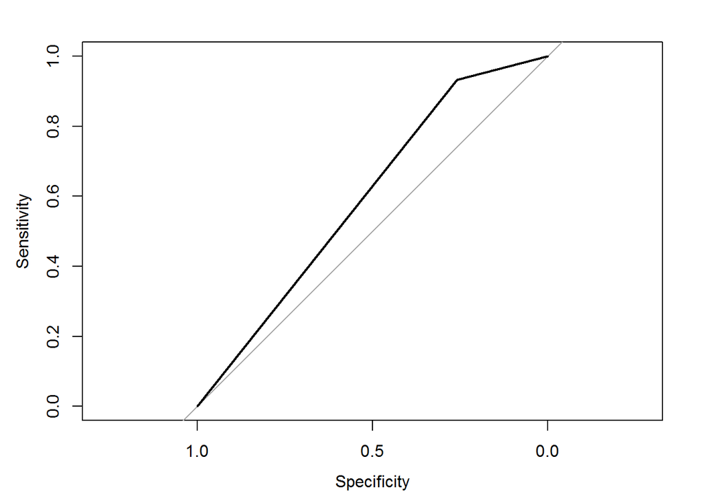

```r
roc_rf <- roc(val_set$is_open,predValid)
plot(roc_rf)
```

# AUC

# We can label this a an fair classisfier but its doing a fair job in the classification with AUC of 0.59

```r
roc_rf
```

```
##
## Call:
## roc.default(response = val_set$is_open, predictor = predValid)
##
## Data: predValid in 2163 controls (val_set$is_open 0) < 6020 cases (val_set$is_open 1).
## Area under the curve: 0.5953
```

# With PCA, optimal mtry was 2 for the pca data set as well

# Accuracy: 72.74%

```r
set.seed(123)
rfmodel_pca <- randomForest(is_open ~ ., data = train_set_pca, ntree = 50, mtry = optimal_mtry, importance = TRUE)
rfmodel_pca
```

```
##
## Call:
##  randomForest(formula = is_open ~ ., data = train_set_pca, ntree = 50,      mtry = optimal_mtry, importance = TRUE)
##                Type of random forest: regression
##                      Number of trees: 50
## No. of variables tried at each split: 2
##
##           Mean of squared residuals: 0.1872984
##                     % Var explained: 4.58
```

```r
predValid_pca <- predict(rfmodel_pca, val_set_pca, type = "response")
predValid_pca <- ifelse(predValid_pca > 0.5,1,0)

caret::confusionMatrix(data = as.factor(predValid_pca), reference = as.factor(val_set$is_open))
```

```
## Confusion Matrix and Statistics
##
##           Reference
## Prediction    0    1
##          0  588  656
##          1 1575 5364
##
##                Accuracy : 0.7274
##                  95% CI : (0.7176, 0.737)
##     No Information Rate : 0.7357
##     P-Value [Acc > NIR] : 0.9567
##
##                   Kappa : 0.1885
##  Mcnemar's Test P-Value : <2e-16
##
##             Sensitivity : 0.27184
##             Specificity : 0.89103
##          Pos Pred Value : 0.47267
##          Neg Pred Value : 0.77302
##              Prevalence : 0.26433
##          Detection Rate : 0.07186
##    Detection Prevalence : 0.15202
##       Balanced Accuracy : 0.58144
##
##        'Positive' Class : 0
##
```

# ROC

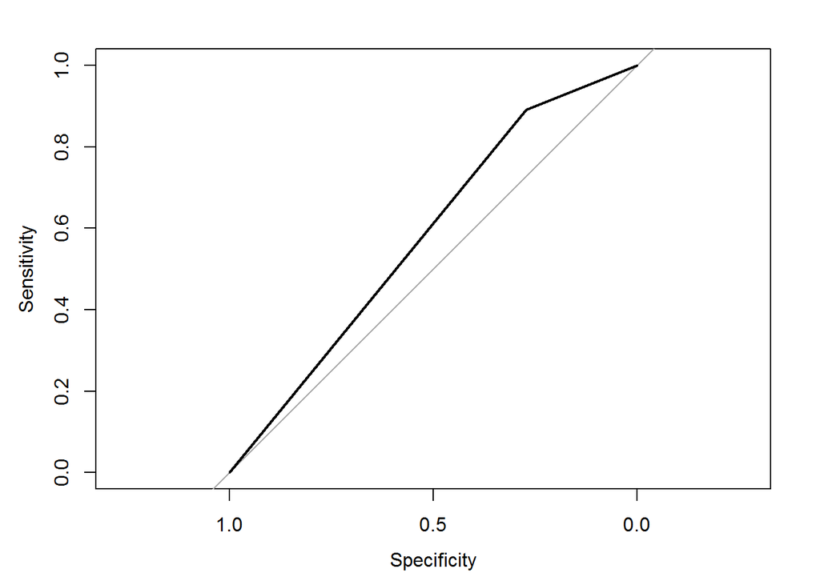

```r
roc_rf_pca <- roc(val_set$is_open,predValid_pca)
plot(roc_rf_pca)
```

# SVM

# Accuracy: rbfdot -> 55.71%

# Accuracy: polydot -> 39.18%

# Accuracy: laplacedot -> 70.89% (AUC: 0.61)

# Here we will be tuning the model by varying the kernels

# By varying the value of cost of constraints violation, there was very little difference in the training error.

# For laplacedot, C values of 10 and 10000, even though the training error reduced with higher C value it was only 0.000053.

# rbfdot

```r
set.seed(123)
sv_rf <- ksvm(is_open ~ ., data = train_set,kernel = "rbfdot",type="nu-svc")

pred_svm_rf <- predict(sv_rf, val_set)
caret::confusionMatrix(data = as.factor(pred_svm_rf), reference = as.factor(val_set$is_open))
```

```
## Confusion Matrix and Statistics
##
##           Reference
## Prediction    0    1
##          0 1160 2621
##          1 1003 3399
##
##                Accuracy : 0.5571
##                  95% CI : (0.5463, 0.5679)
##     No Information Rate : 0.7357
##     P-Value [Acc > NIR] : 1
##
##                   Kappa : 0.0814
##  Mcnemar's Test P-Value : <2e-16
##
##             Sensitivity : 0.5363
##             Specificity : 0.5646
##          Pos Pred Value : 0.3068
##          Neg Pred Value : 0.7721
##              Prevalence : 0.2643
##          Detection Rate : 0.1418
##    Detection Prevalence : 0.4621
##       Balanced Accuracy : 0.5505
##
##        'Positive' Class : 0
##
```